# TSAR Complete Workflow

Candy Gao

2023-06-22

# TSAR Workflow

Pipeline analysis from raw data reading to graphic visualization

## 1. Load Package and other relevant packages

Install package using devtools. Usage of dplyr and ggplot2 along with TSAR package is recommended for enhanced analysis.

```r
library(devtools)
devtools::install_local("/Users/candygao/Desktop/TSAR_0.1.0.tar.gz")
library(TSAR)
library(dplyr)
```

```r
library(ggplot2)
```

## 2. Load Data

Read data in .txt or .csv format. Use read.delim function to input tab delimited file; use read.csv to input comma separated files. Other formats of input are welcomed as long as data is stored in data frame structure as numeric type. Ensure excessive lines are removed. (e.g. skip = , nrows = ) Means to check these are view(), pre-opening data file in excel, or manually removing all excessive data before input reading. Package defaults variable names as “Well.Position”, “Temperature”, “Fluorescence”, “Normalized”. Consider renaming data frame before proceding to following step.

```r
raw_data <- read.csv(file = "/Users/candygao/Desktop/qpcrresult/experiment file/Vitamin_RawData_Thermal Shift_02_162.eds.csv", header = TRUE, nrows = 118176)
```

## 3. Data Pre-Processing

Select data of individual cell for pre-analysis screening. e.g. select well A1

```r
test <- raw_data %>%
  filter(Well.Position == "A01") # select data for one well by well ID

#section data by temperature to remove messy area
#test <- subset(test, test$Temperature>40 & test$Temperature <50)
```

Run example analysis on one well to screen potential errors and enhancement of model.

```r
#normalize fluorescence reading into scale between 0 and 1
test <- normalize(test, fluo = 5, selected = c("Well.Position", "Temperature", "Fluorescence", "Normalized"))
head(test)
```

```
##   Well.Position Temperature Fluorescence Normalized
## 1           A01    21.97290     87464.91  0.4339496
## 2           A01    22.03227     87437.66  0.4337473
## 3           A01    22.09164     87410.72  0.4335473
## 4           A01    22.15101     87384.08  0.4333495
## 5           A01    22.21038     87357.69  0.4331535
## 6           A01    22.26976     87331.48  0.4329590
```

```r
gammodel <- model_gam(test, x = test$Temperature, y = test$Normalized)
test <- model_fit(test, model = gammodel) #, smoothed="Fluorescence")
```

Output analysis result using ggplot to view normalized data and fitted model. Determine is any noise need to be removed (i.e. subsetting by temperature range). Determine which model is the best (i.e. is currrent data already smoothed, does fitted model suit well.) Determine if tm-estimation is proper. *current model assumes derivative estimation of tm value.

```r
tm_est(test)
```

```
## [1] 53.73642
```

```r
view_model(test)
```

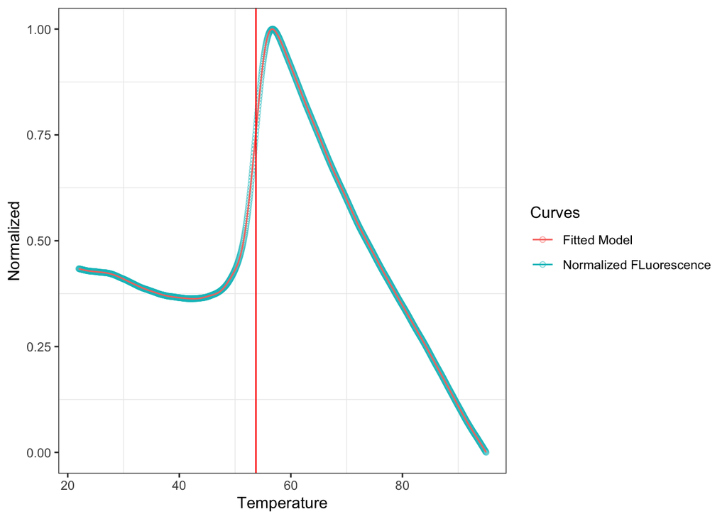

Screen all wells for curve shape on raw_data set and sift out corrupted data. This step is not required but may help remove data modeling errors.

[figure not shown]

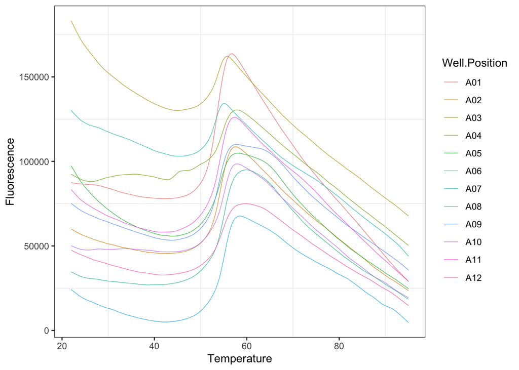

```r
myApp <- weed_raw(raw_data, checkrange= c("A","C","1","12"))
#shiny::runApp(myApp)

t_data <- remove_raw(raw_data,
                     removelist = c('C04','B04','C03','C10','B11','C11','C02',
                                    'C12','C01','B06','C07','C09','C08','B05',
                                    'B07','C06','B12','C05','B08','B02','B01',
                                    'B03','B09','B10'))

t_data <- remove_raw(t_data, removerange = c("D","H","1","12"))
screen(t_data)
```